# 1. Description

### Course STAT467 Multivariate Analysis

#### Semester Fall 2017

#### Content Multivariate Normal Distribution and Its Properties part:3*

#### Notebook Language R

*Notes are mostly from [Applied Multivariate Statistical Analysis (Johnson et al.)](https://www1.udel.edu/oiss/pdf/617.pdf) and [Applied Multivariate Statistical Analysis (Härdle et al.)](https://link.springer.com/book/10.1007%2F978-3-540-72244-1)

```r
library(mvtnorm)
library(ggplot2)
```

# 2. MLE of $\mu$ and $\Sigma$

$$\widehat{\mu}_{MLE} = \bar{X}$$ $$\widehat{\Sigma}_{MLE} = \frac{n-1}{n}S$$

```r
set.seed(108)
n = seq(10, 1000, by = 10)
M = c(0, 0, 0)
V = matrix(c(9, 0, 1, 0, 2, 1, 1, 1, 2), 3, 3)

M1_diff = S1_diff = M2_diff = S2_diff = 0

for(i in 1:length(n)){
    X = rmvnorm(n[i], M, V)

    x_bar = colMeans(X)
    x_median = apply(X, 2, median)

    S = cov(X)
    S_mle = S*((n[i]-1)/n[i])

    M1_diff[i] = sqrt(sum((M-x_bar)^2))
    S1_diff[i] = sqrt(sum((V-S_mle)^2))

    M2_diff[i] = sqrt(sum((M-x_median)^2))
    S2_diff[i] = sqrt(sum((V-S)^2))
}
```

```r
Mus = data.frame(sample_size = n, estimator = rep(c("mean", "median"), each = length(n)), difference = c(M1_diff, M2_diff))
```

```r
Sigmas = data.frame(sample_size = n, estimator = rep(c("Sn", "S"), each = length(n)), difference = c(S1_diff, S2_diff))
```

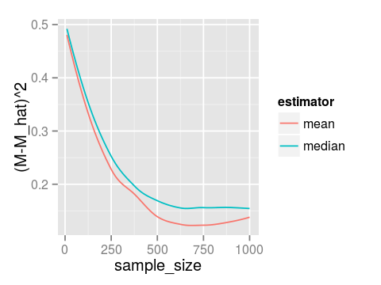

```r
ggplot(Mus, aes(sample_size, difference)) + geom_smooth(method="loess",aes(colour = estimator), se=F) +
ylab("(M-M_hat)^2")
```

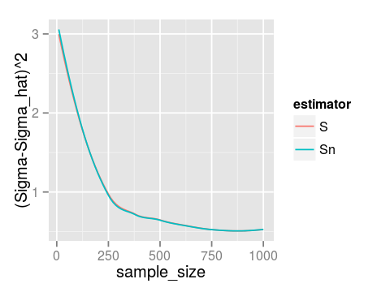

```r
ggplot(Sigmas, aes(sample_size, difference)) + geom_smooth(method="loess",aes(colour = estimator), se=F) +
ylab("(Sigma-Sigma_hat)^2")
```

```r
print(paste("Sum of Sn error = ",sum(S1_diff)))
print(paste("Sum of S error = ",sum(S2_diff)))
```

```
[1] "Sum of Sn error =  89.4876267977734"
[1] "Sum of S error =  89.5435799307478"
```

Sample Mean always better estimator than median for Mu parameter of MVN. However, S and Sn do not differ much.

# 3. Sampling Distribution of $\bar{X}$ and $S $

$$Let \space X \sim N_4(0, \Sigma)$$

where;

$$ \Sigma = \left[ {\begin{array}{cccc} 4 & 0 & 1 & 1\\ 0 & 4 & 0 & 1\\ 1 & 0 & 2 & -2\\ 1 & 1 & -2 & 5\\ \end{array} } \right] $$

```r
set.seed(108)
n = 1000 #sample size

M = matrix(c(0, 0, 0, 0), 4, 1) #poulation mean
S = matrix(c(4, 0, 1,  1, 0, 4, 0,  1, 1, 0, 2, -2, 1, 1, -2, 5), 4, 4) #population covariance

p = 4 #number of variables
k = 1000 #repeatation size

M_hat = matrix(0, k, p) #X_bar matrix
S_hat = array(0, c(k, p, p)) #Sample variance tensor

for(i in 1:k){
  X = rmvnorm(n, M, S)

  M_hat[i, ]= colMeans(X)
  S_hat[i, ,] = cov(X)
}
```

## 3.1 $\bar{X} \sim N_p(\mu, \frac{1}{n} \Sigma)$

We expect a normal distribution with:

```r
print("mean")
M
```

```
[1] "mean"
```

| 0 |
| --- |
| 0 |
| 0 |
| 0 |

```r
print("covariance")
round(S/n,4)
```

```
[1] "covariance"
```

| 0.004 | 0.000 | 0.001 | 0.001 |
| --- | --- | --- | --- |
| 0.000 | 0.004 | 0.000 | 0.001 |
| 0.001 | 0.000 | 0.002 | -0.002 |
| 0.001 | 0.001 | -0.002 | 0.005 |

Here is mean of sample means (sounds weird), it is quite close to $\mu$:

```r
round(colMeans(M_hat), 3)
```

1. -0.003

2. -0.003

3. -0.001

4. 0

```r
round(cov(M_hat), 3)
```

| 0.004 | 0.000 | 0.001 | 0.001 |
| --- | --- | --- | --- |
| 0.000 | 0.004 | 0.000 | 0.001 |
| 0.001 | 0.000 | 0.002 | -0.002 |
| 0.001 | 0.001 | -0.002 | 0.005 |

## 3.2 $(n-1)S \sim W_{n-1}( A | \Sigma)$

```r
print("expected value:")
S
```

```
[1] "expected value:"
```

| 4 | 0 | 1 | 1 |
| --- | --- | --- | --- |
| 0 | 4 | 0 | 1 |
| 1 | 0 | 2 | -2 |
| 1 | 1 | -2 | 5 |

```r
round(colMeans(S_hat),3)
```

| 3.992 | 0.000 | 1.001 | 0.993 |
| --- | --- | --- | --- |
| 0.000 | 4.004 | 0.003 | 0.997 |
| 1.001 | 0.003 | 1.998 | -1.998 |
| 0.993 | 0.997 | -1.998 | 4.995 |

# 4. Large Sample Behaviors of $\bar{X}$ and $S $

$$n(\bar{x}-\mu) \ approximately \ \sim N(0, \Sigma) \tag{1}$$

$$ n(\bar{x}-\mu)S^{-1}(\bar{x}-\mu)^T \ approximately \ \chi^2_{p} \tag{2}$$

No matter what distribution X belongs.

In chapter 3 we briefly analyzed $\bar{X}$ and $S$, now we are going to compare their distributions with expected distributions. I will focus on the second equation.

```r
my_chi=numeric(k)

for(i in 1:k){

  A = M_hat[i, ]-M
  B = solve(S_hat[1, , ])

  my_chi[i] = n*t(A)%*%B%*%A
}
```

let's draw its qqplot with expected values

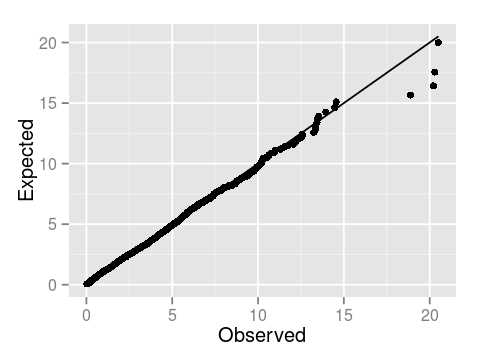

```r
df = data.frame(Expected = qchisq(((1:k)-0.5)/(k), p), Observed = sort(my_chi))

ggplot(df, aes(Observed, Expected)) + geom_point()+
  geom_line(data = data.frame(Observed=c(0, max(df$Observed)), Expected=c(0, max(df$Observed))))
```

# 5. Chi-Squared Q-Q plots to check Multivariate Normality

Let's sample from same distribution again

```r
set.seed(99)
n = 1000
p = 4
X = rmvnorm(n, M, S)
```

$\hat{d_j} = (x_j-\bar{x})^TS^{-1}(x_j-\bar{x})$

$$d \sim \chi^2_p$$

```r
get_d2 = function(X, x_bar, S){

  n = dim(X)[1]
  p = dim(X)[2]
  x_bar = matrix(x_bar, p, 1)
  Sinv = solve(S)

  d2 = numeric(n)

  for(i in 1:n){
    d2[i] = t(X[i,] - x_bar) %*% Sinv %*% (X[i,] - x_bar)
  }

  return(sort(d2))
}
```

```r
S = cov(X)
x_bar = colMeans(X)
d2_hat = get_d2(X, x_bar, S)
```

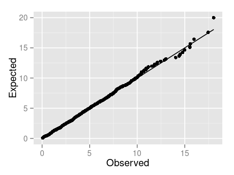

```r
df = data.frame(Expected = qchisq(((1:n)-0.5)/(n), p), Observed = sort(d2_hat))

ggplot(df, aes(Observed, Expected)) + geom_point()+
  geom_line(data = data.frame(Observed=c(0, max(df$Observed)), Expected=c(0, max(df$Observed))))
```

# 6. Inference to $\mu$

## 6.1 Hotelling's $T^2$

$$ H_0 : \mu = \mu_0 \\ \\ H_1 : \mu \neq \mu_0 $$

$$ T^2 = n(\bar{X} - M_0)^T S^{-1} (\bar{X} - M_0) \\ $$

$$ reject \ H_0 \ if \ T^2 > c \ where; \\ $$

$$c = \frac{(n-1) \ p }{n-p}F_{p,n-p,\alpha} \\ $$

Because:

$$ T^2 \sim \frac{(n-1) \ p }{n-p}F_{p,n-p}$$

Lets test above sample with: $$ H_0 : \mu = \left[ {\begin{array}{c} 0\\ 0\\ 0\\ 0\\ \end{array} } \right]\\ \\ H_1 : \mu \neq \left[ {\begin{array}{c} 0\\ 0\\ 0\\ 0\\ \end{array} } \right] $$

and $\alpha = 0.05 $

```r
#Here is first five observation of X
head(X)
```

| 0.5738726 | 1.0637507 | -0.0734442 | 1.0653575 |
| --- | --- | --- | --- |
| -0.8856003 | 0.3300438 | -1.4826496 | 1.5066455 |
| -0.6723912 | -2.3623942 | -1.6991282 | 1.9760481 |
| 0.3516830 | -5.1602121 | -3.4892945 | 1.5589035 |
| -0.4435473 | -3.3530951 | 0.1742847 | -0.3208576 |
| 1.9806630 | 1.3725625 | 0.6145814 | -0.1525796 |

```r
#And variable means:
round(x_bar,2)
```

1. -0.05

2. 0.09

3. -0.01

4. 0.02

```r
HotellingT2 = function(X, M0, alpha = 0.05, plot_it = T){

    n = dim(X)[1]
    p = dim(X)[2]
    x_bar = matrix(colMeans(X), p, 1)
    M0 = matrix(M0, p, 1)
    S = cov(X)

    T2 = n*t(x_bar-M0)%*%solve(S)%*%(x_bar-M0)
    TestStat = T2*((n-p)/(p*(n-1)))
    CriticVal = qf(1-alpha,p,n-p)

    coordx = seq(0,qf(0.99,p,n-p), length = 999 )
    coordy = df(coordx,p,n-p)
    mydf = data.frame(x = coordx, y = coordy)

    print(paste("Hotelling's T^2 =", round(T2, 3)))
    print(paste("Test Statistic =", round(TestStat, 3)))
    print(paste("Critical Value =", round(CriticVal, 3)))

    if(plot_it){
        pl=qplot(x=mydf$x,y=mydf$y,geom="line")
        shade <- rbind(c(CriticVal ,0), mydf[(mydf$x -CriticVal)>0, ], c(mydf[nrow(mydf), "x"], 0))
        return(pl + geom_polygon(data = shade, aes(x, y),fill="purple",alpha=.5) +
               geom_point(data = data.frame(x=TestStat,y=0.01), aes(x, y)))
    }
}
```

```
[1] "Hotelling's T^2 = 2.605"
[1] "Test Statistic = 0.649"
[1] "Critical Value = 2.381"
```

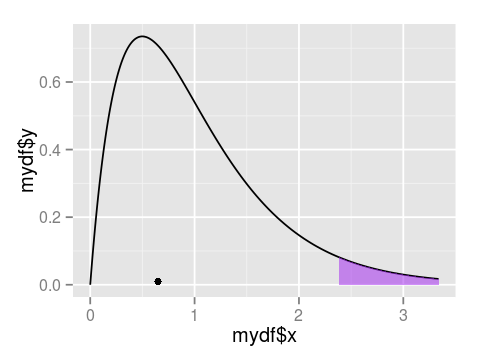

```r
HotellingT2(X, c(0,0,0,0))
```

## 6.2 Likelihood Ratio Test

One could also use LRT to test mean. Now, we will calculate Wilk's Lambda.

$$ \Lambda = \frac{\underset{\Sigma}{\arg\max} L(\mu_0,\Sigma)} {\underset{\Sigma, \mu}{\arg\max} L(\mu, \Sigma)} = \biggl( \frac{|\hat{\Sigma}|}{|\hat{\Sigma_0}|} \biggr)^{n/2} \tag{eq 1} $$

$$ \Lambda^{2/n} = \biggl(1+ \frac{T^2}{(n-1)} \biggr)^{-1} \tag{eq 2} $$

And corresponding distribution is: $$-2ln \Lambda^{1/2} \sim \chi_v^2 $$ $$v = Dim(H) - Dim(H_0)$$

```r
LRT = function(X, M0, alpha = 0.05){

    n = dim(X)[1]
    p = dim(X)[2]
    x_bar = matrix(colMeans(X), p, 1)
    M0 = matrix(M0, p, 1)

    Sigma_hat = matrix(0, p, p)
    for(i in 1:n){
      Sigma_hat = Sigma_hat + (X[i,] - x_bar)%*%t(X[i,] - x_bar)
    }

    Sigma0_hat = matrix(0, p, p)
    for(i in 1:n){
      Sigma0_hat = Sigma0_hat + (X[i,] - M0)%*%t(X[i,] - M0)
    }

    Sigma_hat = Sigma_hat/n
    Sigma0_hat = Sigma0_hat/n

    W_L = (det(Sigma_hat) / det(Sigma0_hat))^(n/2)
    TestStat = -2*log(W_L)
    CriticVal = qchisq(1 - alpha, n - p)

    print(paste("Wilk's Lambda =", round(W_L, 3)))
    print(paste("Test Statistic =", round(TestStat, 3)))
    print(paste("Critical Value =", round(CriticVal, 3)))

}
```

```r
LRT(X, c(0, 0, 0, 0))
```

```
[1] "Wilk's Lambda = 0.272"
[1] "Test Statistic = 2.605"
[1] "Critical Value = 1070.532"
```

Lets check equation 2: